# 1. Computer lab notes 1

### Preparation

- Open rstudio, start a new Rscript (rstudio’s Menu ‘File’, Submenu ‘New File’, Option ‘R Script’), save it (rstudio’s Menu ‘File’, Option ‘Save’) in a folder dedicated to today’s lecture
- Clear your working environment and load the following packages (type the Rcode in your Rscript, use ‘Run’ to ‘Run the current line or selection’)

```r
rm(list=ls())#clear environment

library('ggplot2')#visualization
```

- If you don’t have a given package installed, install it first (see instructions on Moodle); installing&loading a package is like installing&using an app on your phone - you install it once, you load it every time you want to use it
  - **write your own comments/annotations in your Rscript**
  - those below explain syntax and hence are not an example of documentation
  - according to Hadley Wickham: **use comments to explain the “why” not the “what” or “how”**
- Note that the source markdown file (.Rmd) that produced this output file (.html) is available on Moodle, so you can also annotate these notes.
- Optionally, set the working directory accordingly, making sure that the data file(s) (if applicable) is/are in that directory, eg,

```r
#setwd('C:/Users/.../')#uncomment, modify, run
```

### Contents

Today we will be simulating paths of the Wiener Process (aka Standard Brownian Motion), Generalized Wiener Process (aka Brownian Motion), and performing related visualizations in Rpackage ‘ggplot2’: visualization of a path (for a given $\omega$) and visualization of the distribution (for a given $t$). While doing so, we will learn about data.frames and how to manipulate them. We will also see how to save images and how to use loops and write functions. **Follow the links/resources on Moodle to learn more.**

#### Exercise 1

Simulate one path of the Wiener Process on the interval $[0,0.5]$ with a time-step of 0.001 (process starts at 0) and then plot it.

```r
#solution with a 'for' loop (syntax: for(var in seq) { expr })

TT<-0.5 #assign 0.5 to the Rvariable 'TT'
dt<-0.001 #assign 0.001 to the Rvariable 'dt'
tt<-seq(from=0,to=TT,by=dt) #create a sequence 0,0.001,...,0.5
                            #and assign it to the Rvariable 'tt'
head(tt) #show the top of 'tt'
```

```
## [1] 0.000 0.001 0.002 0.003 0.004 0.005
```

```r
zz<-rep(x=NA,times=length(tt)) #create a sequence of NA's of the same length as 'tt'
                             #and assign it to the Rvariable 'zz'
head(zz)
```

```
## [1] NA NA NA NA NA NA
```

```r
zz[1]<-0 #to the first slot of 'zz', assign 0
head(zz)
```

```
## [1]  0 NA NA NA NA NA
```

```r
#'for' loop indexed by Rvariable 'i' with values in the sequence 2,3,...,length(zz)
for(i in 2:length(zz))
{#opening brace of the 'for' loop's instructions
  zz[i]<-zz[i-1]+sqrt(dt)*rnorm(n=1,mean=0,sd=1)
  #to the ith slot of 'zz', assign:
  #the value from the previous slot
  #plus
  #one N(0,1) random variable multiplied by 'sqrt(dt)'
}#closing brace of the 'for' loop's instructions
head(zz)
```

```
## [1]  0.000000000 -0.006353274  0.016436533  0.004757768 -0.041777269
## [6] -0.017874552
```

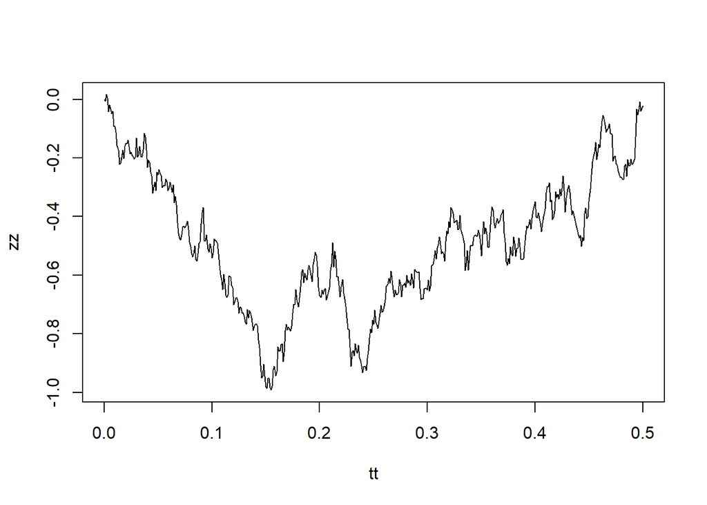

```r
plot(x=tt,y=zz,type='l') #plot 'zz' versus 'tt' using 'line' (l=line)
```

To perform the same task(s) in other programming languages would require similar sort of commands.

```r
#loop-free solution

#'TT', 'dt', 'tt' already declared
head(tt)
```

```
## [1] 0.000 0.001 0.002 0.003 0.004 0.005
```

```r
zz<-cumsum(c(0,sqrt(dt)*rnorm(n=length(tt)-1,mean=0,sd=1)))
#this over-writes 'zz' from the earlier chunk of code
head(zz)
```

```
## [1] 0.00000000 0.03676111 0.09353102 0.06406283 0.06280389 0.13081621
```

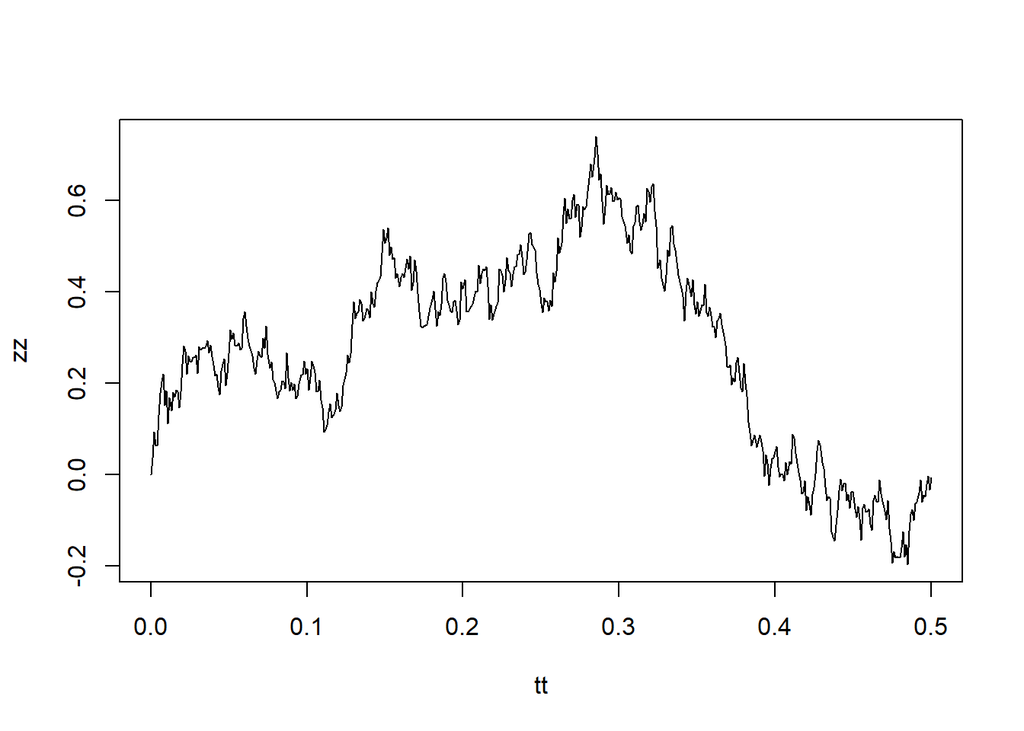

```r
plot(x=tt,y=zz,type='l')
```

The loop-free code is more R-specific. Why are the two paths different?

#### Exercise 2

Create a data.frame called ‘wp1’, which stores Rarrays ‘tt and ’zz’ under variables/columns ‘time and ’value’, respectively. Add an extra column called ‘rep’ with a string ‘1’. Read about Rfunctions ‘paste’ and ‘paste0’.

```r
#'tt', 'zz' already declared

wp1<-data.frame(time=tt,value=zz)
wp1$rep<-paste(1)
#add a new column called 'rep' filled up with a character/string '1';
#because paste(1) is of length one, the software 'recycles' this value
#as many times as the number of rows in wp1
help('paste')
```

Explain the difference between paste(‘TT’) and paste(TT). How would you get the information about the structure of ‘wp1’? How would you extract only that part of ‘wp1’ for which ‘value’ is non-negative?

#### Exercise 3

Make a graph of your path again, but this time using ‘ggplot2’ package and ‘wp1’.

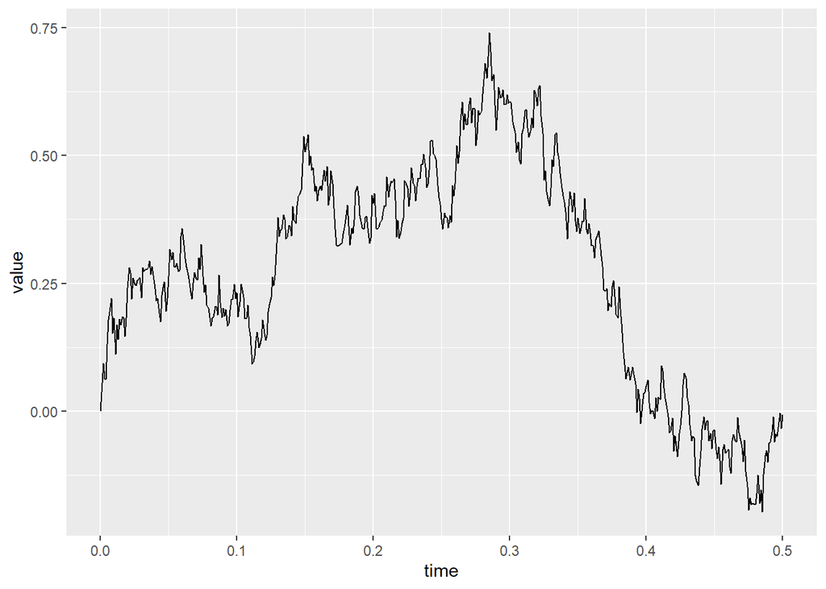

```r
ggplot(data=wp1,aes(x=time,y=value))+geom_line()# aes = aesthetics
```

#### Exercise 4

Simulate another path of the Wiener Process and store it (together with Rvector ‘tt’) as a data.frame called ‘wp2’. Add an extra column called ‘rep’ with a string ‘2’.

```r
#'TT', 'dt', 'tt' already declared

zz<-cumsum(c(0,sqrt(dt)*rnorm(n=length(tt)-1,mean=0,sd=1)))
wp2<-data.frame(time=tt,value=zz,rep=paste(2))
```

#### Exercise 5

Combine the two data.frames, row-wise, into one called ‘wp’ using Rfunction ‘rbind’. Plot both paths in the same graph, using different colours for different paths/replicates.

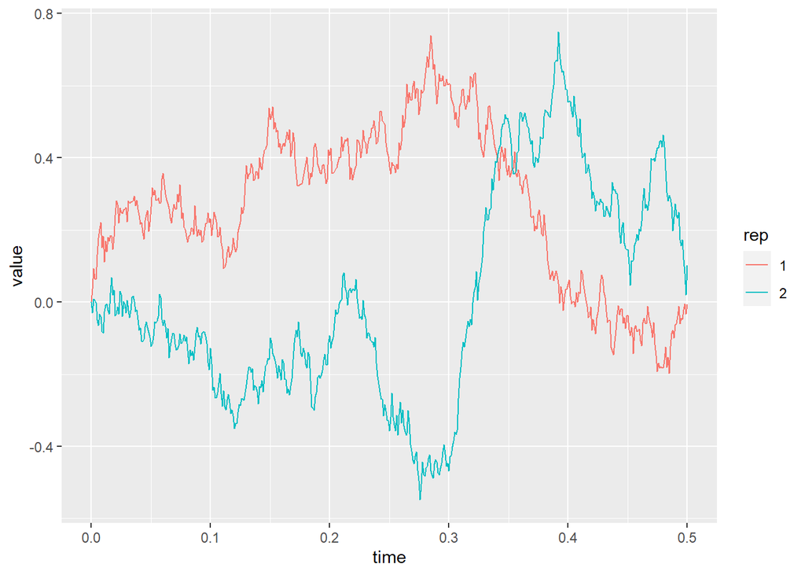

```r
# Rpackage 'ggplot2' already loaded

wp<-rbind(wp1,wp2)
ggplot(data=wp,aes(x=time,y=value,col=rep))+geom_line()
```

#### Exercise 6

More efficiency/automation: use ‘for’ loop to create data.frame ‘wp’ of the previous exercise.

```r
#'TT', 'dt', 'tt' already declared

wp<-NULL
#'NULL' is a reserved word in R
# create/prepare an Rvariable 'wp' (with a 'NULL' value)
# for collecting/appending all the paths
for(rr in 1:2)
{
  zz<-cumsum(c(0,sqrt(dt)*rnorm(n=length(tt)-1,mean=0,sd=1)))

  temp<-data.frame(time=tt,value=zz,rep=paste(rr))
  #create an auxilary/temporary data frame and assign it to an Rvariable 'temp'

  wp<-rbind(wp,temp)
  #append (row-wise) the auxilary/temporary data frame to the Rvariable 'wp'
  #and update 'wp'
}
str(wp)
```

```
## 'data.frame':    1002 obs. of  3 variables:
##  $ time : num  0 0.001 0.002 0.003 0.004 0.005 0.006 0.007 0.008 0.009 ...
##  $ value: num  0 0.00225 0.03295 0.02876 -0.00379 ...
##  $ rep  : chr  "1" "1" "1" "1" ...
```

#### Exercise 7

Even more efficiency/automation: write a user-defined Rfunction called ‘WP’ which for a given interval $[0,T]$ and time-step $\Delta t$ will simulate $R$ paths of the Wiener Process and will return a data.frame with all the paths, tagging the paths with the path/replication index (in string/character format). The input arguments should be: ‘TT, dt, RR’. Clear the workspace before you begin. Read about ‘function’ in R, eg, at https://www.datamentor.io/r-programming/function/ or https://www.statmethods.net/management/userfunctions.html

```r
rm(list=ls())#clear the workspace

#syntax for an Rfunction called 'WP'
#with arguments TT,dt,RR
#(there are no default values for the arguments);
#purpose:
#to generate RR (tagged) paths of the
#Wiener Process on [0,TT]
#input:
#TT: [num] end point of the time interval [0,TT]
#dt: [num] time increment to discretize [0,TT]
#RR: [int] number of paths
#output: data.frame (with three variables/columns)
#        with RR tagged paths

WP<-function(TT,dt,RR)
{#opening brace of the Rfunction
  tt<-seq(from=0,to=TT,by=dt)
  result<-NULL
  for(rr in 1:RR)
  {
    zz<-cumsum(c(0,sqrt(dt)*rnorm(n=length(tt)-1)))
    temp<-data.frame(time=tt,value=zz,rep=paste(rr))
    result<-rbind(result,temp)
  }
  return(result)
  #return the Rvariable 'result' as the value of the Rfunction
}#closing brace of the Rfunction
```

Rvariables used inside the function are defined locally, i.e., not accessible outside it. Test it. What is the benefit of declaring an Rfunction? We dropped ‘mean’ and ‘sd’ arguments from Rfunction ‘rnorm’. By doing so, we assume that these arguments take on the default values, which in this case are 0 and 1, respectively. If you declare ‘WP()’  
without default values for its arguments, executing ‘WP()’ will produce an error. What happens if you execute ‘WP’ (no paretheses)?

#### Exercise 8

Use your function to obtain a data.frame with 100 paths of the Standard Brownian Motion on $[0,1.5]$. Use time increment of 0.001. Plot all the paths using ‘ggplot’ Rfunction. Use different colours to distinguish between different paths, but do not display the legend.

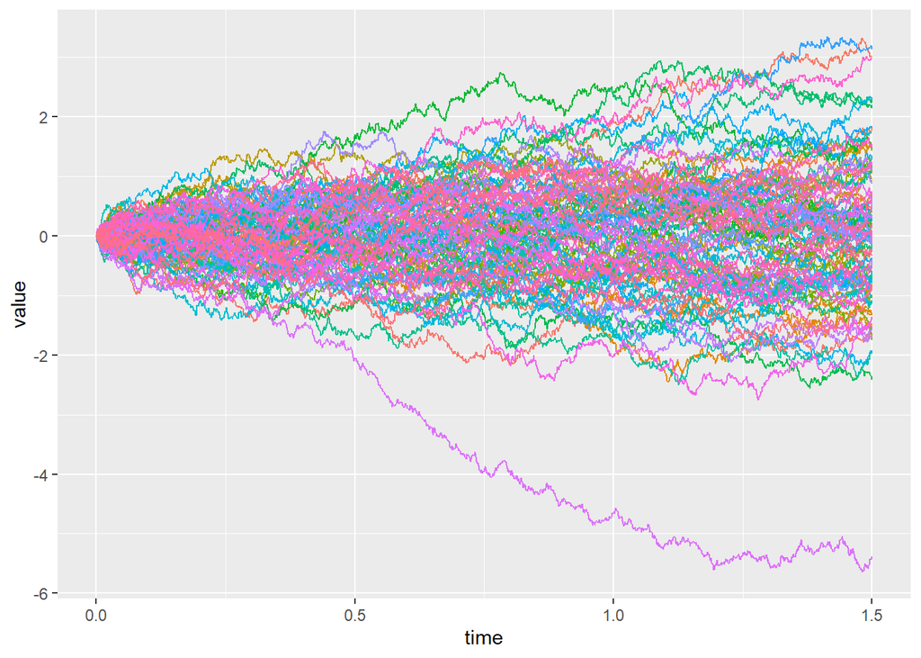

```r
output<-WP(TT=1.5,dt=0.001,RR=100)#correction here
gg<-ggplot(data=output,aes(x=time,y=value,col=rep))+geom_line()
gg<-gg+theme(legend.position='none')
print(gg)
```

#### Exercise 9

With the data from the previous exercise, visualize the distribution of the random variable $Z_t$ for $t \in \{0.4,1.0,1.2\}$ using a boxplot.

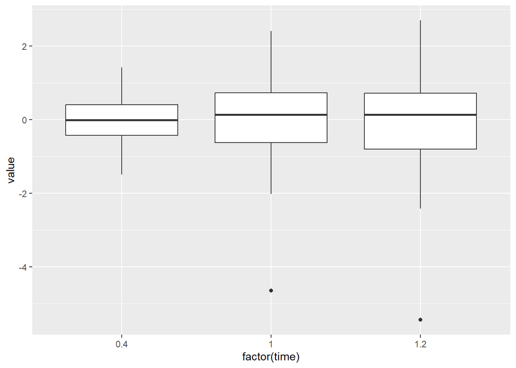

```r
bb<-ggplot(data=output[output$time %in% c(0.4,1.0,1.2),],
           aes(x=factor(time),y=value))+geom_boxplot()
print(bb)
```

```r
output[output$time %in% c(0.4,1.0,1.2),]
```

```
##        time        value rep
## 401     0.4 -1.255802386   1
## 1001    1.0 -1.007153890   1
## 1201    1.2 -1.362285804   1
## 1902    0.4  0.198153890   2
## 2502    1.0  0.656545118   2
## 2702    1.2  1.347447535   2
## 3403    0.4 -0.022518310   3
## 4003    1.0  1.162633353   3
## 4203    1.2  0.853876340   3
## 4904    0.4  0.516455760   4
## 5504    1.0  0.438237036   4
## 5704    1.2  0.350197866   4
## 6405    0.4 -0.311053085   5
## 7005    1.0 -1.606254795   5
```

[output cut: 286 more lines]

```r
#extracts the relevant part of 'output'
```

Theoretically, what is the distribution of the random variable $Z_{0.4}$? - Give its name and the value(s) of the parameter(s). And of $Z_{1}$? And of $Z_{1.2}$?

Inside ‘aes’ we had to convert numerical ‘time’ to a ‘factor’ (here, factor=categorical variable).  
If we failed to do so, the boxplot(s) would have been based on un-grouped data, rather than on grouped (by ‘time’) data.

#### Exercise 10

With the data from the previous exercise, visualize the distribution of the random variable $Z_t$ for $t \in \{0.4,1.0,1.2\}$ using a histogram with an area of 1. Set the bin-width to 0.2, fill the bins red with thick black borders and swap the axes around.

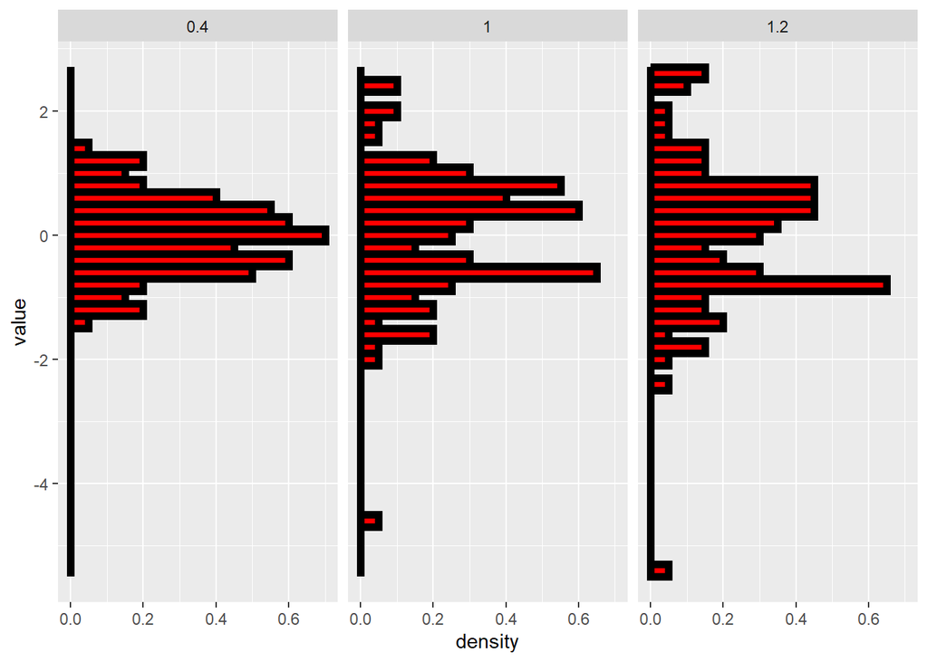

```r
hh<-ggplot(data=output[output$time %in% c(0.4,1.0,1.2),],
           aes(x=value))
hh<-hh+geom_histogram(aes(y = ..density..),binwidth=0.2,
                      fill='red',col='black',size=2)
hh<-hh+facet_grid(.~time)+coord_flip()
print(hh)
```

#### Exercise 11

Save the last image as ‘wphist.jpg’ file - specify the path (as a string, ie, between quotes of the destination file. If you don’t specify the path, the file will be sent to your current working directory. Remember to close all the graphical windows beforehand. You can also use rstudio’s menus to save images.

```r
#getwd()#get your working directory

graphics.off() #close all the graphical windows
jpeg(file='wphist.jpg') #open a destination jpeg file
print(hh) #make a graph - it will be sent to the file, not to 'rstudio'
dev.off()#close the destination file
```

#### Exercise 12

Simulate one path of the Generalized Wiener Process (Rvariable ‘xx’) with a drift $a=-0.01$ and diffusion $b=0.02$ on the interval $[0,0.5]$ with a time-step of 0.001 (process starts at $x_0=0$ by default). Store ‘tt’ and ‘xx’ as a data.frame using some useful tagging. Plot ‘xx’ versus ‘tt’ using ‘ggplot’.

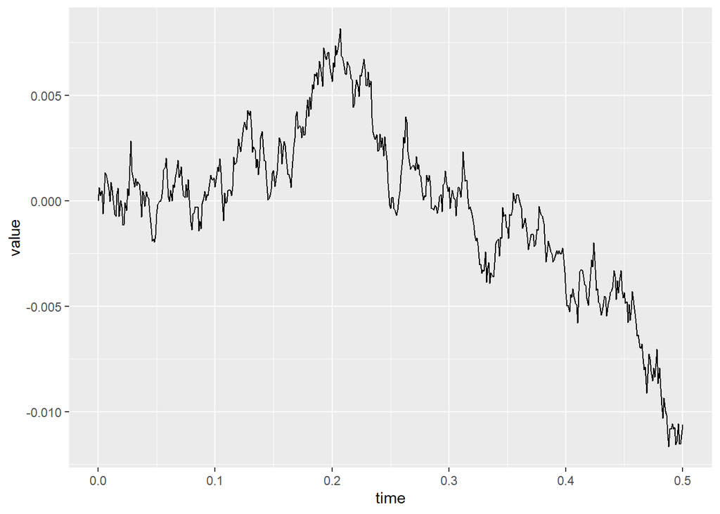

```r
#'TT', 'dt', 'tt' need to be declared first
# we declare them again as we cleared the workspace

TT<-0.5 #assign 0.5 to the Rvariable 'TT'
dt<-0.001 #assign 0.001 to the Rvariable 'dt'
tt<-seq(from=0,to=TT,by=dt) #create a sequence 0,0.001,...,0.5
                            #and assign it to the Rvariable 'tt'

aa<- -0.01
bb<-0.02
rr<-1#replicate 1
xx<-cumsum(c(0,aa*dt+bb*sqrt(dt)*rnorm(n=length(tt)-1)))
temp<-data.frame(time=tt,value=xx,rep=paste(rr),
                 drift=paste(aa),diffusion=paste(bb))
ggplot(data=temp,aes(x=time,y=value))+geom_line()
```